# New_file

kumar

2025-03-30

## Purpose

This analysis project focuses on Bike uses in the New York city and client want to know the difference between the Subscribers and Non Subscribes and also wants to get strategies for converting Non subscribers into Subscribers to boost the company’s revenue. He also want to know the most busiest start and end station, Which bikes are used most, peak uses hours etc. So it is our responsibility is to present the findings to the client so that he can use then to take necessary steps to reach its goals.

## install and load the necessary packages

We will install and load the neccesary packages that are required for data cleaning, data analysis and visualization such as *tidyverse*, *dplyr* and so on.

```r
# install.packages(c("readxl","dplyr","lubridate","tidyverse"))
library(readxl)
library(dplyr)
library(lubridate)
library(tidyverse)
```

```r
library(ggplot2)
```

## import the .csv file

Now we will import the *citi-bike-trip-data.csv* file and check the structure of the data to know about its rows and columns

```r
file_path <- "C:/Users/DELL/Downloads/DA_files/Citi-Bike-Trip-Data.csv"

df <- read_csv(file_path)
head(df)
```

```
## # A tibble: 6 × 16
##   tripduration ...2  starttime           stoptime            `start station id`
##          <dbl> <lgl> <dttm>              <dttm>                           <dbl>
## 1          364 NA    2017-09-01 00:02:01 2017-09-01 00:08:05               3183
## 2          357 NA    2017-09-01 00:08:12 2017-09-01 00:14:09               3187
## 3          432 NA    NA                  2017-09-01 00:17:24               3195
## 4          934 NA    2017-09-01 00:10:11 2017-09-01 00:25:46               3272
## 5          932 NA    2017-09-01 00:10:16 2017-09-01 00:25:48               3272
## 6          414 NA    2017-09-01 00:15:32 2017-09-01 00:22:26               3186
## # ℹ 11 more variables: `start station name` <chr>,
## #   `start station latitude` <dbl>, `start station longitude` <dbl>,
## #   `end station id` <dbl>, `end station name` <chr>,
## #   `end station latitude` <dbl>, `end station longitude` <dbl>, bikeid <dbl>,
## #   usertype <chr>, `birth year` <chr>, gender <dbl>
```

```r
# check the structure of the file
str(df)
```

```
## spc_tbl_ [33,119 × 16] (S3: spec_tbl_df/tbl_df/tbl/data.frame)
##  $ tripduration           : num [1:33119] 364 357 432 934 932 414 625 178 557 220 ...
##  $ ...2                   : logi [1:33119] NA NA NA NA NA NA ...
##  $ starttime              : POSIXct[1:33119], format: "2017-09-01 00:02:01" "2017-09-01 00:08:12" ...
##  $ stoptime               : POSIXct[1:33119], format: "2017-09-01 00:08:05" "2017-09-01 00:14:09" ...
##  $ start station id       : num [1:33119] 3183 3187 3195 3272 3272 ...
##  $ start station name     : chr [1:33119] "Exchange Place" "Warren St" "Sip Ave" "Jersey & 3rd" ...
##  $ start station latitude : num [1:33119] 40.7 40.7 40.7 40.7 40.7 ...
##  $ start station longitude: num [1:33119] -74 -74 -74.1 -74 -74 ...
##  $ end station id         : num [1:33119] 3276 3199 3280 3207 3207 ...
##  $ end station name       : chr [1:33119] "Marin Light Rail" "Newport Pkwy" "Astor Place" "Oakland Ave" ...
##  $ end station latitude   : num [1:33119] 40.7 40.7 40.7 40.7 40.7 ...
##  $ end station longitude  : num [1:33119] -74 -74 -74.1 -74.1 -74.1 ...
##  $ bikeid                 : num [1:33119] 29670 26163 26273 26297 29247 ...
##  $ usertype               : chr [1:33119] "Subscriber" "Subscriber" "Subscriber" "Subscriber" ...
##  $ birth year             : chr [1:33119] "1989" "1980" "1988" "1991" ...
##  $ gender                 : num [1:33119] 1 1 1 1 2 0 1 1 1 1 ...
##  - attr(*, "spec")=
##   .. cols(
##   ..   tripduration = col_double(),
##   ..   ...2 = col_logical(),
##   ..   starttime = col_datetime(format = ""),
##   ..   stoptime = col_datetime(format = ""),
##   ..   `start station id` = col_double(),
##   ..   `start station name` = col_character(),
##   ..   `start station latitude` = col_double(),
##   ..   `start station longitude` = col_double(),
##   ..   `end station id` = col_double(),
##   ..   `end station name` = col_character(),
##   ..   `end station latitude` = col_double(),
##   ..   `end station longitude` = col_double(),
##   ..   bikeid = col_double(),
##   ..   usertype = col_character(),
##   ..   `birth year` = col_character(),
##   ..   gender = col_double()
##   .. )
##  - attr(*, "problems")=<externalptr>
```

```r
colnames(df)
```

```
##  [1] "tripduration"            "...2"
##  [3] "starttime"               "stoptime"
##  [5] "start station id"        "start station name"
##  [7] "start station latitude"  "start station longitude"
##  [9] "end station id"          "end station name"
## [11] "end station latitude"    "end station longitude"
## [13] "bikeid"                  "usertype"
## [15] "birth year"              "gender"
```

## Check for missing values and drop the empty column

Now we will check for any missing values in our data. Because missing values can cause the problem during the data analysis or they can lead to wrong conclusions.we can see that column **…2** is empty so we will remove it.

```r
# check for missing values
colSums(is.na(df))
```

```
##            tripduration                    ...2               starttime
##                       0                   33119                       1
##                stoptime        start station id      start station name
##                       0                       0                       0
##  start station latitude start station longitude          end station id
##                       0                       0                       0
##        end station name    end station latitude   end station longitude
##                       0                       0                       0
##                  bikeid                usertype              birth year
##                       0                       0                       0
##                  gender
##                       0
```

## remove the *…2* column

Now we will remove the *…2* column as it is not required for our analysis or we can say that we can not clearly understand which variable do it represent.

```r
df <- df %>%
  select(-`...2`)
```

## Fill the missing values

We can see that in starttime column there is missing value so we will fill the missing values using median() and mode() method

```r
df$tripduration[is.na(df$tripduration)] <- median(df$tripduration, na.rm = TRUE)
df$starttime[is.na(df$starttime)] <- median(df$starttime, na.rm = TRUE)

get_mode <- function(v) {
  uniq_values <- unique(v)
  uniq_values[which.max(tabulate(match(v, uniq_values)))]
}

# filling the missing values with mode
mode_user_type <- get_mode(df$usertype)
df$usertype[is.na(df$usertype)] <- mode_user_type

# median is used when missing values are numerical while mode is
# used when missing values are categorical

# Verifyning if there are still any missing values.
colSums(is.na(df))
```

```
##            tripduration               starttime                stoptime
##                       0                       0                       0
##        start station id      start station name  start station latitude
##                       0                       0                       0
## start station longitude          end station id        end station name
##                       0                       0                       0
##    end station latitude   end station longitude                  bikeid
##                       0                       0                       0
##                usertype              birth year                  gender
##                       0                       0                       0
```

So clearly we can see that there are no missing values now.

## Rename the columns for better readability

We can also rename the columns for better readability such as tripduration can be renamed as Trip_duration and stoptime can be renames as Stop_Time and so on.

```r
colnames(df) <- c("Trip_Duration", "Start_Time", "Stop_Time","Start_Station_id","Start_station_name",
                  "Start_Station_latitude","Start_Station_longitude", "End_Station_id","End_station_name",
                  "End_Station_latitude","End_Station_longitude", "Bike_ID", "User_Type",
                  "Birth_Year", "Gender")

colnames(df)
```

```
##  [1] "Trip_Duration"           "Start_Time"
##  [3] "Stop_Time"               "Start_Station_id"
##  [5] "Start_station_name"      "Start_Station_latitude"
##  [7] "Start_Station_longitude" "End_Station_id"
##  [9] "End_station_name"        "End_Station_latitude"
## [11] "End_Station_longitude"   "Bike_ID"
## [13] "User_Type"               "Birth_Year"
## [15] "Gender"
```

## Convert the datatypes of variables to make them of consistent format

Here we will convert the datatype of Start_Time, Stop_Time to datetime and convert User_Type column to appropriate format.

```r
# convert the datatype
# convert to datetime columns
df$Start_Time <- as.POSIXct(df$Start_Time, format="%Y-%m-%d %H:%M:%S")
df$Stop_Time <- as.POSIXct(df$Stop_Time, format="%Y-%m-%d %H:%M:%S")

# convert the User_Type column
df$User_Type <- as.factor(df$User_Type)
```

## Create new columns

Here we will create new column such as Start_Hour which will be made by extracting the value from the Start_Time column. Similarly Start_Day column will extracted from the Start_Time column and so on. New columns represent information such as start hour, day and month of the trip so that we can have an idea of exacttly when the trip starts.

```r
# create new columns
# extract hour day and month
df$Start_Hour <- hour(df$Start_Time)
df$Start_Day <- day(df$Start_Time)
df$Start_Month <- month(df$Start_Time, label = TRUE)

# trip duration in minutes
df$Trip_Duration_Minutes <- as.numeric(difftime(df$Stop_Time, df$Start_Time, units = "mins"))
```

## Remove the outliers

Now we can see that there are few columns where Start_Time is greater than the Stop_Time which is invalid because Start_Time can not be greater that the Stop_Time. So now we will remove such rows to get a cleaner data.

```r
df <- df %>% filter(Trip_Duration_Minutes > 0)

# verify changes
View(df)
```

## Data Analysis

Now we will analyse our data to get the insights out of it. Using these insights we can reach to a conclusion as the what the steps should be taken to reach out goals.

```r
# summary of data
summary(df)
```

```
##  Trip_Duration         Start_Time
##  Min.   :     61.0   Min.   :2017-09-01 00:02:01.00
##  1st Qu.:    238.0   1st Qu.:2017-09-09 13:40:06.50
##  Median :    355.0   Median :2017-09-16 11:15:06.00
##  Mean   :    756.9   Mean   :2017-09-16 11:19:32.10
##  3rd Qu.:    610.0   3rd Qu.:2017-09-23 10:05:11.00
##  Max.   :2181628.0   Max.   :2017-09-30 23:47:53.00
##
##    Stop_Time                      Start_Station_id Start_station_name
##  Min.   :2017-09-01 00:08:05.00   Min.   :3183     Length:33118
##  1st Qu.:2017-09-09 13:56:31.50   1st Qu.:3187     Class :character
##  Median :2017-09-16 11:27:22.50   Median :3203     Mode  :character
##  Mean   :2017-09-16 11:32:09.51   Mean   :3217
##  3rd Qu.:2017-09-23 10:14:31.00   3rd Qu.:3225
##  Max.   :2017-10-01 01:33:32.00   Max.   :3481
##
##  Start_Station_latitude Start_Station_longitude End_Station_id
##  Min.   :40.69          Min.   :-74.10          Min.   : 128
##  1st Qu.:40.72          1st Qu.:-74.05          1st Qu.:3186
##  Median :40.72          Median :-74.04          Median :3202
##  Mean   :40.72          Mean   :-74.05          Mean   :3217
##  3rd Qu.:40.73          3rd Qu.:-74.04          3rd Qu.:3220
##  Max.   :40.75          Max.   :-74.03          Max.   :3481
##
##  End_station_name   End_Station_latitude End_Station_longitude    Bike_ID
##  Length:33118       Min.   : 0.00        Min.   :-74.10        Min.   :15250
##  Class :character   1st Qu.:40.72        1st Qu.:-74.05        1st Qu.:26280
##  Mode  :character   Median :40.72        Median :-74.04        Median :29284
##                     Mean   :39.97        Mean   :-72.68        Mean   :28500
##                     3rd Qu.:40.73        3rd Qu.:-74.04        3rd Qu.:29577
##                     Max.   :40.78        Max.   :  0.00        Max.   :31957
##
##       User_Type      Birth_Year            Gender        Start_Hour
##  Customer  : 2133   Length:33118       Min.   :0.000   Min.   : 0.00
##  Subscriber:30985   Class :character   1st Qu.:1.000   1st Qu.: 9.00
##                     Mode  :character   Median :1.000   Median :14.00
##                                        Mean   :1.141   Mean   :13.52
##                                        3rd Qu.:1.000   3rd Qu.:18.00
##                                        Max.   :2.000   Max.   :23.00
##
##    Start_Day      Start_Month    Trip_Duration_Minutes
##  Min.   : 1.00   Sep    :33118   Min.   :    1.02
##  1st Qu.: 9.00   Jan    :    0   1st Qu.:    3.97
##  Median :16.00   Feb    :    0   Median :    5.93
##  Mean   :15.89   Mar    :    0   Mean   :   12.62
##  3rd Qu.:23.00   Apr    :    0   3rd Qu.:   10.17
##  Max.   :30.00   May    :    0   Max.   :36360.48
##                  (Other):    0
```

## Most popular Start_stations

We will find the most popular stations where the trip starts.

```r
# most popular stations
most_papular_stations <- df %>%
  count(Start_station_name, sort = TRUE) %>%
  head(5)
print(most_papular_stations)
```

```
## # A tibble: 5 × 2
##   Start_station_name     n
##   <chr>              <int>
## 1 Grove St PATH       4079
## 2 Hamilton Park       2415
## 3 Exchange Place      2146
## 4 Sip Ave             1671
## 5 Newport PATH        1487
```

We can see that **Grove St PATH** is the most popular station where trips start.

## Find most popular end station

```r
# most popular end station
most_popular_end_station <- df %>%
  count(End_station_name, sort = TRUE) %>%
  head(1)
print(most_popular_end_station)
```

```
## # A tibble: 1 × 2
##   End_station_name     n
##   <chr>            <int>
## 1 Grove St PATH     5005
```

We can see that **Grove St PATH** is also most popular end station as well.

## Peak uses hour

Now we will find peak uses hours for cycles i.e. when cycles are in use most of the time.This will help the stakeholder to know when more cycles should be made available and we previously also calculated the most popular start and end stations so stakeeholder will know where most cycles should be made available.

```r
# peak uses hour
peak_uses_hour <- df %>%
  group_by(Start_Hour) %>%
  summarise(Trips = n()) %>%
  arrange(desc(Trips))
print(peak_uses_hour)
```

```
## # A tibble: 24 × 2
##    Start_Hour Trips
##         <int> <int>
##  1          8  3572
##  2         18  3360
##  3         17  2979
##  4         19  2414
##  5          7  2286
##  6          9  2143
##  7         16  1864
##  8         12  1583
##  9         20  1528
## 10         13  1484
## # ℹ 14 more rows
```

So we can see that 8,18 and 17 are the most busiest hours so it is recommended that more cycles should be made available during these hours.

## Bike uses

Now we will calculate that which bikes used most so that we can figure out that those bikes shold be made available in more numbers.

```r
# bike uses analysis
bike_uses<- df %>%
  count(Bike_ID, sort = TRUE) %>%
  head(10)
print(bike_uses)
```

```
## # A tibble: 10 × 2
##    Bike_ID     n
##      <dbl> <int>
##  1   26303   140
##  2   26229   134
##  3   26208   132
##  4   26223   131
##  5   26242   124
##  6   26170   119
##  7   29243   117
##  8   26219   115
##  9   26283   115
## 10   26317   115
```

We can say that bikes 26303,26229 and 26208 are most used by the riders so it is feasible that that these bikes should be made available in appropriate number in appropriate stations.

## Data visualization

Now we will visualize the insights so that audience can easily understand it. When data is presented using visualizations such as scatter plot, pie chart, bar chart or column chart, user who do not have a data science background can also easily understand. **Note*:* Visualization should be presented in such a way that user can understand it within 5 seconds and in next 5 seconds he should be able to extract the insights.

## Find out if user is Customer or Subscriber

Purpose of our analysis to find the ways to convert the casual riders into subscribers

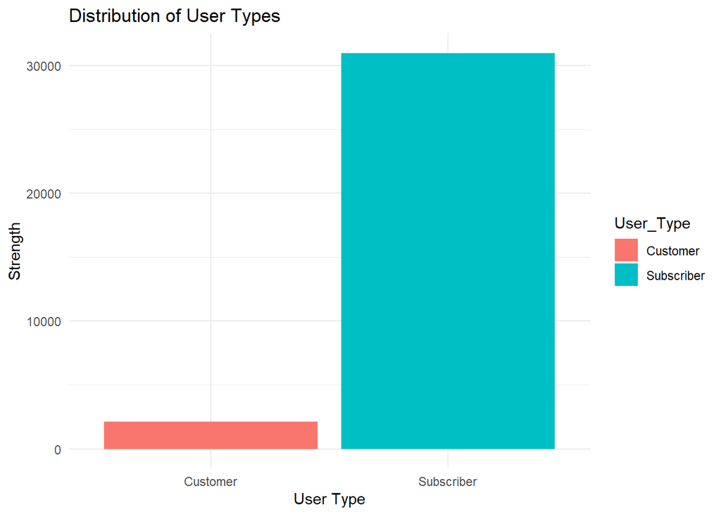

```r
ggplot(data = df) + geom_bar(mapping = aes(x =User_Type,
  fill = User_Type)) +
  theme_minimal() +
  labs(title = "Distribution of User Types",x = 'User Type', y = 'Strength')
```

So we can see that majority of our users are Subscribers.

## Trips over time

Now we will find out trips over a period of time and compare them

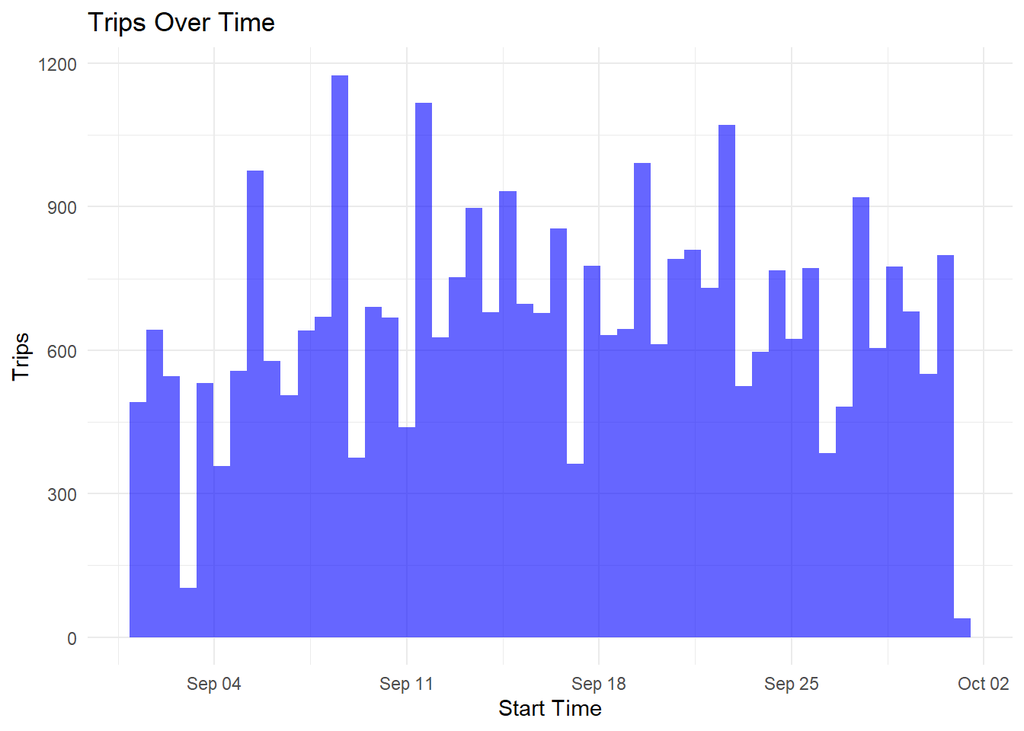

```r
ggplot(data = df) + geom_histogram(mapping = aes(x = Start_Time), fill = "blue",
  bins = 50, alpha = 0.6) +
  theme_minimal() +
  labs(title = "Trips Over Time", x = "Start Time", y = "Trips")
```

## Bike uses by hour and day

Now we will visualize the bike uses by hour and day to find out which days are busiest and also in that days which hours are busiest. It will give us the idea as to when the bike should be made available in large numbers.

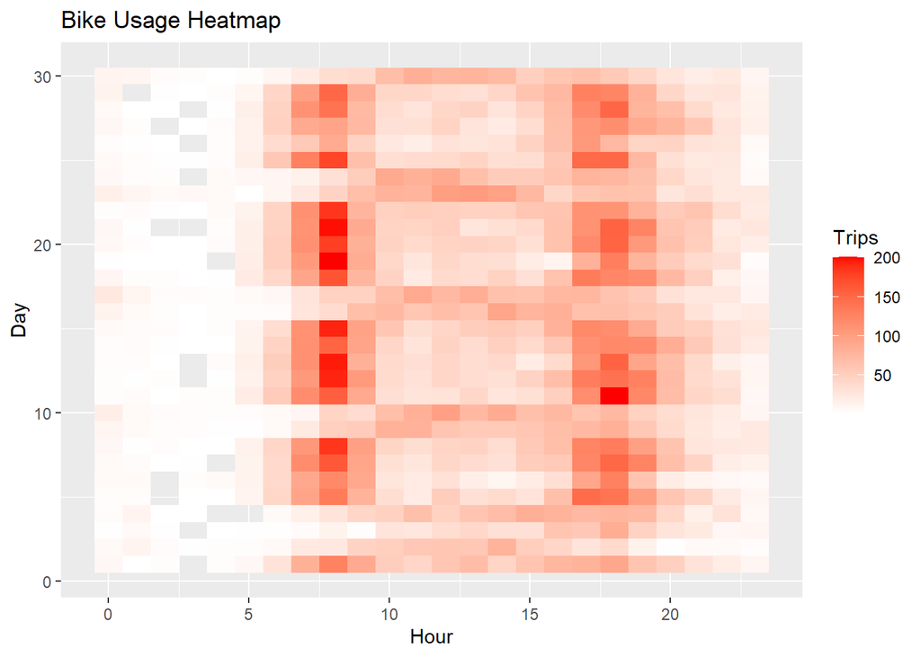

```r
df %>%
  group_by(Start_Day, Start_Hour) %>%
  summarise(Trips = n()) %>%
  ggplot(aes(Start_Hour, Start_Day, fill = Trips)) +
  geom_tile() +
  scale_fill_gradient(low = "white", high = "red") +
  labs(title = "Bike Usage Heatmap", x = "Hour", y = "Day")
```

Given heat map shows most busiest days and hours.

## Bike uses column chart

Given column chart shows top 10 most used bike. So these bikes should be made available at appropriate stations.So that riders can easily access these bike at those stations. This column chart represents bikes by Bike Id metric.

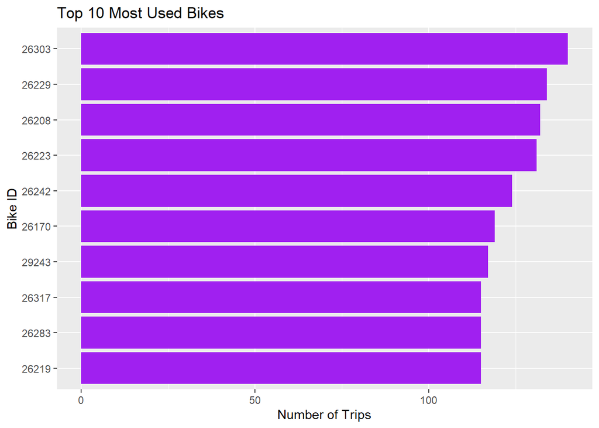

```r
df %>%
  count(Bike_ID) %>%
  top_n(10) %>%
  ggplot(aes(x = reorder(Bike_ID, n), y = n)) +
  geom_col(fill = "purple") +
  coord_flip() +
  labs(title = "Top 10 Most Used Bikes", x = "Bike ID", y = "Number of Trips")
```